# PD4_iml2020

## Praca domowa 4

## COMPAS

### 1. dla Random Forest

```python
#dla obserwacji o max predykcji
explain_model(model_rf, X_train, X_test, y_train, y_test,4353,['age','priors_count'],X_train.columns.values.tolist())
```

```
WARNING:root:Model is unlabeled...
 You can add label using method set_label
```

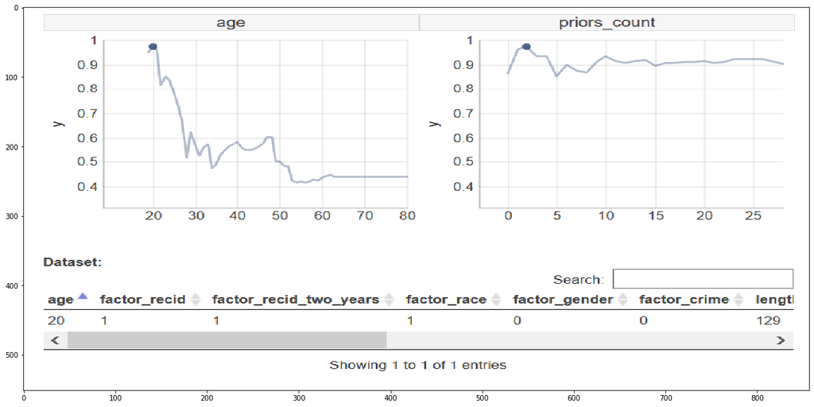

```python
plt.figure(figsize = (20,10))
image = mpimg.imread("iml_1.png")
plt.imshow(image,aspect='auto')
plt.show()
```

Powyższy wykres przedstawia wykres Ceteris Paribus dla pojedynczej obserwacji o numerze 4353, dla której model przewidział najwyższy wynik w zbiorze testowym. Ta osoba ma 20 lat - wartość zmiennej age (wiek). Gdyby wartość tej zmiennej była większa, czyli osoba byłaby starsza, to przy niezmienionych pozostałych zmiennych prawdopodobieństwo, że ta osoba zostanie recydywistą znacznie by się zmniejszyło. Zmienna priors_count, czyli liczba dokonanych wcześniej przestępstw. Niezależnie od tego, ile ta osoba dokonałaby przestępstw, p-stwo, że zostanie ona recydywistą właściwie nie ulegnie znaczącej zmianie, wciąż jest bardzo wysoka.

```python
explain_model(model_rf, X_train, X_test, y_train, y_test,4044,['age','priors_count'],X_train.columns.values.tolist())
```

```
WARNING:root:Model is unlabeled...
 You can add label using method set_label
```

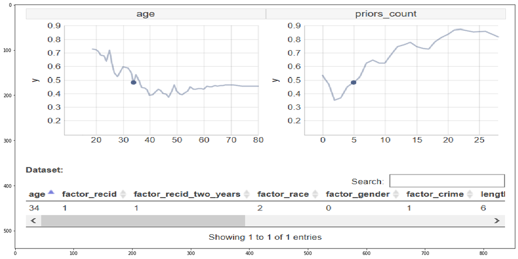

```python
plt.figure(figsize = (20,10))
image = mpimg.imread("iml_2.png")
plt.imshow(image,aspect='auto')
plt.show()
```

Powyższy wykres przedstawia wykres Ceteris Paribus dla pojedynczej obserwacji o numerze 4044. Ta osoba ma 34 lata - wartość zmiennej age (wiek). Gdyby wartość tej zmiennej była większa, czyli osoba byłaby starsza, to przy niezmienionych wartościach pozostałych zmiennych prawdopodobieństwo, że ta osoba zostanie recydywistą nieznacznie by się zmniejszyło. Gdyby ta osoba była młodsza, można by twierdzić, że p-stwo, że ta osoba zostanie recydywistą byłoby dużo większe, ale być może wtedy różniłyby się wartości innych zmiennych, np. liczba dokonanych wcześniej przestępstw (priors_count), wobec czego takie wnioski dotyczące wieku mogą być mylne, gdyż przestępca dokonuje zbrodni w czasie. Zmienna priors_count, czyli liczba dokonanych wcześniej przestępstw. Gdyby ta osoba dokonała większej liczby przestępstw, skutkowałoby to znacznym wzrost p-stwa, że ta osoba zostanie recydywistą.

```python
#dla obserwacji o min predykcji
explain_model(model_rf, X_train, X_test, y_train, y_test,905,['age','priors_count'],X_train.columns.values.tolist())
```

```
WARNING:root:Model is unlabeled...
 You can add label using method set_label
```

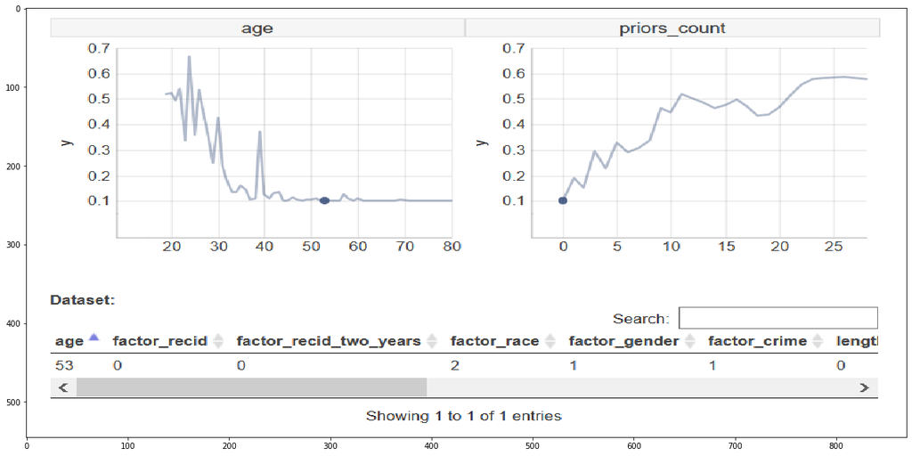

```python
plt.figure(figsize = (20,10))
image = mpimg.imread("iml_3.png")
plt.imshow(image,aspect='auto')
plt.show()
```

Powyższy wykres przedstawia wykres Ceteris Paribus dla pojedynczej obserwacji o numerze 905, dla której model przewidział najniższy wynik w zbiorze testowym. Ta osoba ma 53 lata - wartość zmiennej age (wiek). Gdyby wartość tej zmiennej była większa, czyli osoba byłaby starsza, to przy niezmienionych wartościach pozostałych zmiennych prawdopodobieństwo, że ta osoba zostanie recydywistą nie zmieniłoby się. Zmienna priors_count, czyli liczba dokonanych wcześniej przestępstw. Gdyby ta osoba dokonała większej liczby przestępstw, skutkowałoby to znacznym wzrostem p-stwa, że ta osoba zostanie recydywistą.

### 2. dla XGBoost

```python
explain_model(xgb, X_train, X_test, y_train, y_test,4353,['age','priors_count'],X_train.columns.values.tolist())
```

```
WARNING:root:Model is unlabeled...
 You can add label using method set_label
```

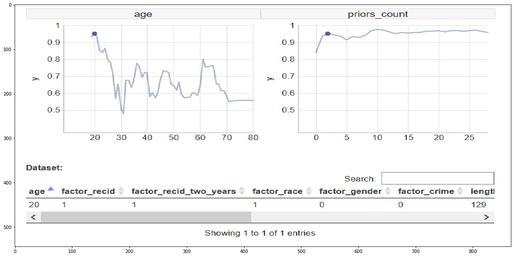

```python
plt.figure(figsize = (20,10))
image = mpimg.imread("iml_4.png")
plt.imshow(image,aspect='auto')
plt.show()
```

Powyższy wykres przedstawia wykres Ceteris Paribus dla pojedynczej obserwacji o numerze 4353. Profile CP różnią się tu między modelami dla zmiennej age. Dla modelu XGBoost nie obserwujemy trendu jak to było w przypadku modelu Random Forest, tylko jakby pewną sezonowość, co wydaje się nieco dziwne w przypadku zmiennej dotyczącej wieku i jej wpływu na p-stwo, ze ktoś zostanie recydywistą.

### Załącznik

```python
import pandas as pd
import numpy as np
import matplotlib.pyplot as plt
from sklearn.preprocessing import LabelEncoder
from sklearn.model_selection import train_test_split
from sklearn.metrics import accuracy_score
from sklearn.metrics import r2_score, mean_squared_error, mean_absolute_error
from sklearn.ensemble import RandomForestRegressor
from sklearn.feature_selection import RFE
import xgboost
from xgboost import XGBRegressor
```

```python
from ceteris_paribus.explainer import explain
from ceteris_paribus.plots.plots import plot_notebook, plot
from ceteris_paribus.profiles import individual_variable_profile
```

```python
import matplotlib.pyplot as plt
import matplotlib.image as mpimg
```

```python
def explain_model(model,X_train,X_test,y_train,y_test,obs,selected_variables,columns):
    explainer=explain(model,columns,X_test,y_test)
    cp=individual_variable_profile(explainer,X_test.loc[obs],y_test.loc[obs])
    #plot_notebook(cp,selected_variables=selected_variables)
```

```python
raw_data = pd.read_csv("compas-scores-two-years.csv")

df = raw_data[["age", "c_charge_degree", "race", "age_cat", "score_text", "sex", "priors_count",
               "days_b_screening_arrest", "decile_score", "is_recid",
               "two_year_recid", "c_jail_in", "c_jail_out"]]
```

```python
df = df[df["days_b_screening_arrest"] <= 30]
df = df[df["days_b_screening_arrest"] >= -30]
df = df[df["is_recid"] != -1]
df = df[df["c_charge_degree"] != "0"]
df = df[df["score_text"] != 'N/A']

df["prob_score"] = df.apply(lambda row: row['decile_score']/10, axis=1)
#df["length_of_stay"] = pd.to_numeric(pd.to_datetime(df["c_jail_out"]) - pd.to_datetime(df["c_jail_in"]))
df["length_of_stay"] = pd.to_datetime(df["c_jail_out"]) - pd.to_datetime(df["c_jail_in"])
df["length_of_stay_in_days"] = pd.to_numeric(df["length_of_stay"].dt.days)
df["factor_recid"], _ = pd.factorize(df["is_recid"])
df["factor_recid_two_years"], _ = pd.factorize(df["two_year_recid"])
df["factor_race"], _  = pd.factorize(df["race"])
df["factor_gender"], _ = pd.factorize(df["sex"])
df["factor_crime"], _ = pd.factorize(df["c_charge_degree"])
df["factor_score"], _ = pd.factorize(df["score_text"])
df["numeric_jail_in"] = pd.to_datetime(df["c_jail_in"])
#df["factor_age"],_ = pd.factorize(df["age_cat"])
df.shape
```

```
(6172, 23)
```

```python
regression_model_df = df[["age",
    "factor_recid",
    "factor_recid_two_years",
    "factor_race",
    "factor_gender",
    "factor_crime",
    "length_of_stay_in_days",
    "priors_count"]]

label = df["prob_score"]
```

```python
X_train, X_test, y_train, y_test = train_test_split(regression_model_df, label, test_size=0.2, random_state=0)
```

### Model Random Forest

```python
def classifier(model):
    model.fit(X_train, y_train)
    pred = model.predict(X_test)
    mse, mae, rscore = mean_squared_error(y_test, pred), mean_absolute_error(y_test, pred), r2_score(y_test, pred)
    print(f"MSE: {mse}, MAE: {mae}, R^2 score: {rscore}")
    return model, pred
```

```python
model_rf, pred_rf = classifier(RandomForestRegressor(n_estimators = 100, random_state = 0))
```

```
MSE: 0.04702225049933595, MAE: 0.16775175755643368, R^2 score: 0.41362080157690895
```

### Model XGBoost

```python
xgb = XGBRegressor(objective='reg:logistic')
xgb.fit(X_train, y_train)
```

```
XGBRegressor(base_score=0.5, booster=None, colsample_bylevel=1,
             colsample_bynode=1, colsample_bytree=1, gamma=0, gpu_id=-1,
             importance_type='gain', interaction_constraints=None,
             learning_rate=0.300000012, max_delta_step=0, max_depth=6,
             min_child_weight=1, missing=nan, monotone_constraints=None,
             n_estimators=100, n_jobs=0, num_parallel_tree=1,
             objective='reg:logistic', random_state=0, reg_alpha=0,
             reg_lambda=1, scale_pos_weight=1, subsample=1, tree_method=None,
             validate_parameters=False, verbosity=None)
```

```python
y_pred_train_xgb=xgb.predict(X_train)
y_pred_test_xgb=xgb.predict(X_test)
```